# Energy Usage Analysis

An Analysis of Solar Generation Effectiveness

Stuart Gow

19 October 2024

# Introduction

(20 Marks)

## Scope of The Data

This analysis looks at the generation and domestic use of solar energy during September 2024 in the southern highlands of Scotland. The objectives of this analysis are to see how well solar generation covers the demands of a domestic residence at the tail end of the summer and to determine if additional solar generation and battery storage is needed. Being able to ensure solar generated power covers all household needs is important as this reduces the financial cost of having to import electricity from the national power grid. It is also a small contribution to the reduction of non-green energy energy generation.

The data comprises three main parts:

- Weather: Daily temperature and solar irradiance readings
- Power Generation & Use: Daily solar energy generated and consumed
- House Occupation: A simple flag to indicate if the house is occupied or not

All data and also supporting files can be found online at [Github](https://github.com/StuartG24/Home-Solar-Usage-Analysis)

### Weather

Weather data is sourced from a local weather station[^1]. Temperature is the mean daily temperature in $^\circ$C and is derived from 6 readings taken at 4 hourly intervals during a 24 hour period. Solar irradiance[^2] is a measure of the solar energy experienced over a specified area and is measure in W/m$^2$; typically this is used to actually calculate the power generated from an array of solar panels, but here it is used here as a proxy for daily sunshine hours because this data was not available.

### Power Generation & Use

Power data is downloaded from an iPhone App that controls the distribution of power to the domestic house being analysed, see Figure 1. This is a Tesla Powerwall and controller that takes electricity from: i) an array of 36 solar panels; ii) battery storage; iii) the national power grid and then intelligently routes this for: i) consumption by the house; ii) battery storage; iii) export to the national power grid. Electricity is measured here in kWh.

[figure not shown]

Tesla Powerwall App

### Data Analysed

Once the three sources of data have been collated the dataset for analysis consists of the below:

First 6 Rows of the source dataset

| Date | Home | From_Solar | From_Grid | To_Grid | From_Battery | To_Battery | Temp_Avg | Irradiance | Occupied |
| --- | --- | --- | --- | --- | --- | --- | --- | --- | --- |
| 2024-09-01 | 19.0 | 2.4 | 11.4 | 0.0 | 11.7 | 0 | 12.9 | 365.9 | 1 |
| 2024-09-02 | 11.3 | 1.2 | 17.3 | 0.0 | 5.2 | 0 | 13.4 | 335.4 | 0 |
| 2024-09-03 | 13.9 | 6.4 | 10.5 | 0.0 | 7.1 | 0 | 9.9 | 1346.8 | 0 |
| 2024-09-04 | 16.2 | 6.8 | 7.4 | 0.0 | 9.3 | 0 | 9.5 | 1722.5 | 0 |
| 2024-09-05 | 18.0 | 11.0 | 11.5 | 0.1 | 9.1 | 0 | 14.5 | 1681.8 | 1 |
| 2024-09-06 | 16.0 | 14.7 | 0.4 | 1.0 | 11.0 | 0 | 16.6 | 1489.4 | 1 |

The dataset consists of:

- 30 observations, for each day in September 2024
- Home: The total electricity, kWh, used by the home all day
- From_ Solar, Grid, Battery: The total electricity provided by the solar panels, power grid and battery respectively. All kWh.
- To_ Grid, Battery: The total electricity exported to the power grid or stored by battery. All kWh.

[figure not shown]

First plot

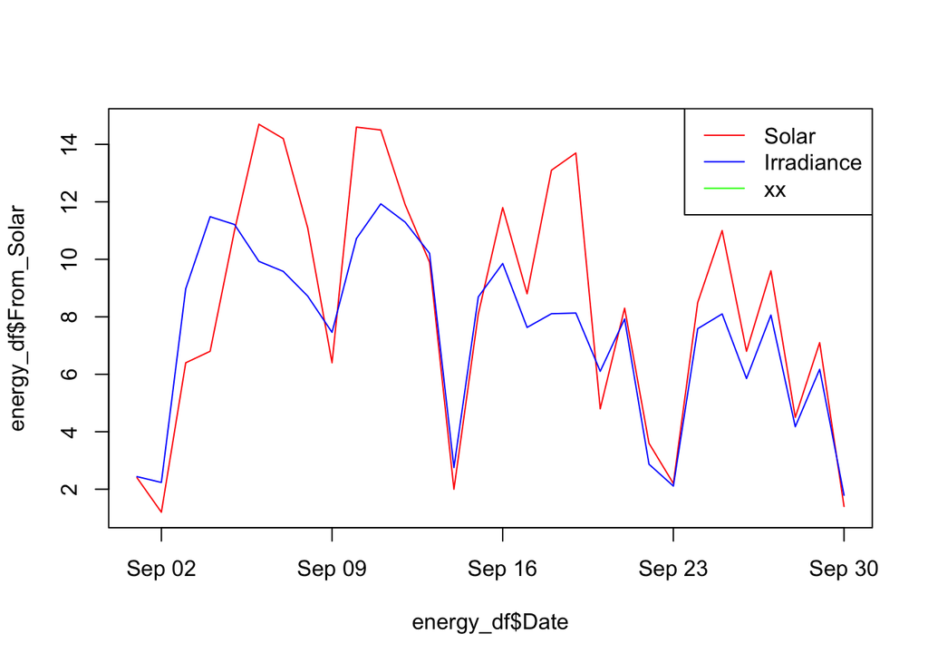

Second plot

# Methods and Results

(40 marks)

# Conclusions

(20 marks)

# References

Crawley, M.J. (2014) *Statistics: An introduction using R*. 2nd Edition. John Wiley & Sons.

Fraix-Burnet, D. (2016) ‘Introduction to R’, *Statistics for Astrophysics: Clustering and Classification*, Volume 77(2016), pp. 3–12. Available at: https://doi.org/10.1051/eas/1677002.

Spiegel, M.R. and Schiller, J. (2012) *Schaum’s outline probability and statistics*. 4th edn. McGraw Hill.

[^1]: Balqhuidder Village Hall: https://www.blscc.org/weather
[^2]: Wikipedia: [https://en.wikipedia.org/wiki/Solar_irradiance](https://en.wikipedia.org/wiki/Solar_irradiance#)